# Introduction to tidyverse

## BASIC TIDYVERSE

### Load libraries

How to load tidyverse libraries in R. It is the easiest way to load all core tidyverse packages using one command in the environment (ggplot2, purr, tibble, dplyr, tidyr, stringr, readr, forcats)

```r
library(tidyverse)
```

### Pipe operator

This is an example of filtering observations from a dataframe without using the pipe operator

| Sepal.Length | Sepal.Width | Petal.Length | Petal.Width | Species |
| --- | --- | --- | --- | --- |
| 5.1 | 3.5 | 1.4 | 0.2 | setosa |
| 4.9 | 3.0 | 1.4 | 0.2 | setosa |
| 4.7 | 3.2 | 1.3 | 0.2 | setosa |
| 4.6 | 3.1 | 1.5 | 0.2 | setosa |
| 5.0 | 3.6 | 1.4 | 0.2 | setosa |
| 5.4 | 3.9 | 1.7 | 0.4 | setosa |
| 4.6 | 3.4 | 1.4 | 0.3 | setosa |
| 5.0 | 3.4 | 1.5 | 0.2 | setosa |
| 4.4 | 2.9 | 1.4 | 0.2 | setosa |
| 4.9 | 3.1 | 1.5 | 0.1 | setosa |

[output cut: 40 more lines]

The pipe operator %>% basically chaining arguments together in a clear way.

| Sepal.Length | Sepal.Width | Petal.Length | Petal.Width | Species |
| --- | --- | --- | --- | --- |
| 5.1 | 3.5 | 1.4 | 0.2 | setosa |
| 4.9 | 3.0 | 1.4 | 0.2 | setosa |
| 4.7 | 3.2 | 1.3 | 0.2 | setosa |
| 4.6 | 3.1 | 1.5 | 0.2 | setosa |
| 5.0 | 3.6 | 1.4 | 0.2 | setosa |
| 5.4 | 3.9 | 1.7 | 0.4 | setosa |
| 4.6 | 3.4 | 1.4 | 0.3 | setosa |
| 5.0 | 3.4 | 1.5 | 0.2 | setosa |
| 4.4 | 2.9 | 1.4 | 0.2 | setosa |
| 4.9 | 3.1 | 1.5 | 0.1 | setosa |

[output cut: 40 more lines]

Advantages:  
- You’ll avoid nested function calls  
- You’ll minimize the need for local variables and function definitions  
- Easy to add steps anywhere in the sequence of operations.

As you’re getting more familiar with tidyverse you will understand the power of this concept.

## DATA WRANGLING

Main Libraries: dplyr, tibble, stringr, readr, forcats

### Filtering observations

Use filter() to subset observations from multiple variables.

| Sepal.Length | Sepal.Width | Petal.Length | Petal.Width | Species |
| --- | --- | --- | --- | --- |
| 5.1 | 3.5 | 1.4 | 0.2 | setosa |
| 4.9 | 3.0 | 1.4 | 0.2 | setosa |
| 4.7 | 3.2 | 1.3 | 0.2 | setosa |
| 4.6 | 3.1 | 1.5 | 0.2 | setosa |
| 5.0 | 3.6 | 1.4 | 0.2 | setosa |
| 5.4 | 3.9 | 1.7 | 0.4 | setosa |
| 4.6 | 3.4 | 1.4 | 0.3 | setosa |
| 5.0 | 3.4 | 1.5 | 0.2 | setosa |
| 4.9 | 3.1 | 1.5 | 0.1 | setosa |
| 5.4 | 3.7 | 1.5 | 0.2 | setosa |

[output cut: 35 more lines]

### Arranging observations

arrange() sorts a dataframe based on one variable

| Sepal.Length | Sepal.Width | Petal.Length | Petal.Width | Species |
| --- | --- | --- | --- | --- |
| 4.3 | 3.0 | 1.1 | 0.1 | setosa |
| 4.4 | 2.9 | 1.4 | 0.2 | setosa |
| 4.4 | 3.0 | 1.3 | 0.2 | setosa |
| 4.4 | 3.2 | 1.3 | 0.2 | setosa |
| 4.5 | 2.3 | 1.3 | 0.3 | setosa |
| 4.6 | 3.1 | 1.5 | 0.2 | setosa |
| 4.6 | 3.4 | 1.4 | 0.3 | setosa |
| 4.6 | 3.6 | 1.0 | 0.2 | setosa |
| 4.6 | 3.2 | 1.4 | 0.2 | setosa |
| 4.7 | 3.2 | 1.3 | 0.2 | setosa |

[output cut: 140 more lines]

Use arrange() to sort a table based on two or more variables

| Sepal.Length | Sepal.Width | Petal.Length | Petal.Width | Species |
| --- | --- | --- | --- | --- |
| 4.3 | 3.0 | 1.1 | 0.1 | setosa |
| 4.4 | 3.0 | 1.3 | 0.2 | setosa |
| 4.4 | 3.2 | 1.3 | 0.2 | setosa |
| 4.4 | 2.9 | 1.4 | 0.2 | setosa |
| 4.5 | 2.3 | 1.3 | 0.3 | setosa |
| 4.6 | 3.6 | 1.0 | 0.2 | setosa |
| 4.6 | 3.4 | 1.4 | 0.3 | setosa |
| 4.6 | 3.2 | 1.4 | 0.2 | setosa |
| 4.6 | 3.1 | 1.5 | 0.2 | setosa |
| 4.7 | 3.2 | 1.3 | 0.2 | setosa |

[output cut: 140 more lines]

### Arranging observations in descending order

| Sepal.Length | Sepal.Width | Petal.Length | Petal.Width | Species |
| --- | --- | --- | --- | --- |
| 7.9 | 3.8 | 6.4 | 2.0 | virginica |
| 7.7 | 3.8 | 6.7 | 2.2 | virginica |
| 7.7 | 2.6 | 6.9 | 2.3 | virginica |
| 7.7 | 2.8 | 6.7 | 2.0 | virginica |
| 7.7 | 3.0 | 6.1 | 2.3 | virginica |
| 7.6 | 3.0 | 6.6 | 2.1 | virginica |
| 7.4 | 2.8 | 6.1 | 1.9 | virginica |
| 7.3 | 2.9 | 6.3 | 1.8 | virginica |
| 7.2 | 3.6 | 6.1 | 2.5 | virginica |
| 7.2 | 3.2 | 6.0 | 1.8 | virginica |

[output cut: 140 more lines]

### Change an existing variable with mutate()

mutate() adds or alter a variable

| Sepal.Length | Sepal.Width | Petal.Length | Petal.Width | Species |
| --- | --- | --- | --- | --- |
| 10.2 | 3.5 | 1.4 | 0.2 | setosa |
| 9.8 | 3.0 | 1.4 | 0.2 | setosa |
| 9.4 | 3.2 | 1.3 | 0.2 | setosa |
| 9.2 | 3.1 | 1.5 | 0.2 | setosa |
| 10.0 | 3.6 | 1.4 | 0.2 | setosa |
| 10.8 | 3.9 | 1.7 | 0.4 | setosa |
| 9.2 | 3.4 | 1.4 | 0.3 | setosa |
| 10.0 | 3.4 | 1.5 | 0.2 | setosa |
| 8.8 | 2.9 | 1.4 | 0.2 | setosa |
| 9.8 | 3.1 | 1.5 | 0.1 | setosa |

[output cut: 140 more lines]

### Use mutate() to add a new column

Add a new variable in the dataframe

| Sepal.Length | Sepal.Width | Petal.Length | Petal.Width | Species | Sepal.Length_2 |
| --- | --- | --- | --- | --- | --- |
| 5.1 | 3.5 | 1.4 | 0.2 | setosa | 10.2 |
| 4.9 | 3.0 | 1.4 | 0.2 | setosa | 9.8 |
| 4.7 | 3.2 | 1.3 | 0.2 | setosa | 9.4 |
| 4.6 | 3.1 | 1.5 | 0.2 | setosa | 9.2 |
| 5.0 | 3.6 | 1.4 | 0.2 | setosa | 10.0 |
| 5.4 | 3.9 | 1.7 | 0.4 | setosa | 10.8 |
| 4.6 | 3.4 | 1.4 | 0.3 | setosa | 9.2 |
| 5.0 | 3.4 | 1.5 | 0.2 | setosa | 10.0 |
| 4.4 | 2.9 | 1.4 | 0.2 | setosa | 8.8 |
| 4.9 | 3.1 | 1.5 | 0.1 | setosa | 9.8 |

[output cut: 140 more lines]

### Combine Filtering, Arranging & Mutating

| Sepal.Length | Sepal.Width | Petal.Length | Petal.Width | Species | Sepal.Length2 |
| --- | --- | --- | --- | --- | --- |
| 4.5 | 2.3 | 1.3 | 0.3 | setosa | 9.0 |
| 4.4 | 2.9 | 1.4 | 0.2 | setosa | 8.8 |
| 4.4 | 3.0 | 1.3 | 0.2 | setosa | 8.8 |
| 4.4 | 3.2 | 1.3 | 0.2 | setosa | 8.8 |
| 4.3 | 3.0 | 1.1 | 0.1 | setosa | 8.6 |

## TIDYING DATA

Main Libraries: tidyr, tibble

Tidy datasets are easy to manipulate, model, visualize and have a specific structure.

### What is tidy data?

A set of data in a specific form:

- Each variable is a column
- Each observation is a row
- Each value is a cell

This is an example of a messy dataset

```r
datasets::WorldPhones
```

```
     N.Amer Europe Asia S.Amer Oceania Africa Mid.Amer
1951  45939  21574 2876   1815    1646     89      555
1956  60423  29990 4708   2568    2366   1411      733
1957  64721  32510 5230   2695    2526   1546      773
1958  68484  35218 6662   2845    2691   1663      836
1959  71799  37598 6856   3000    2868   1769      911
1960  76036  40341 8220   3145    3054   1905     1008
1961  79831  43173 9053   3338    3224   2005     1076
```

Here each column presents the number of phones in a specific area. Each row presents the number of phones per specific year. It is messy & very difficult to handle e.g. analyze, model…

This is an example of a tidy dataset

| Sepal.Length | Sepal.Width | Petal.Length | Petal.Width | Species |
| --- | --- | --- | --- | --- |
| 5.1 | 3.5 | 1.4 | 0.2 | setosa |
| 4.9 | 3.0 | 1.4 | 0.2 | setosa |
| 4.7 | 3.2 | 1.3 | 0.2 | setosa |
| 4.6 | 3.1 | 1.5 | 0.2 | setosa |
| 5.0 | 3.6 | 1.4 | 0.2 | setosa |
| 5.4 | 3.9 | 1.7 | 0.4 | setosa |
| 4.6 | 3.4 | 1.4 | 0.3 | setosa |
| 5.0 | 3.4 | 1.5 | 0.2 | setosa |
| 4.4 | 2.9 | 1.4 | 0.2 | setosa |
| 4.9 | 3.1 | 1.5 | 0.1 | setosa |

[output cut: 140 more lines]

### Gather

Essentially it takes a “wide” dataframe with a lot of columns and transforms it to “long”. It takes the following arguments:

1. the key, where you create the group variable
2. the value, which is the value variable (usually numeric)
3. The columns you want to group

Use gather() to make a tidy dataframe

| year | Area | Phones |
| --- | --- | --- |
| 1951 | N.Amer | 45939 |
| 1956 | N.Amer | 60423 |
| 1957 | N.Amer | 64721 |
| 1958 | N.Amer | 68484 |
| 1959 | N.Amer | 71799 |
| 1960 | N.Amer | 76036 |
| 1961 | N.Amer | 79831 |
| 1951 | Europe | 21574 |
| 1956 | Europe | 29990 |
| 1957 | Europe | 32510 |

[output cut: 39 more lines]

### Spread

It converts a long dataframe into a wide dataframe. In practice it reverses the gather function, so it does the opposite of making tidy dataset. Sometimes it is used as an intermediate step in data transformation or when creating tables for reports or presentations

| year | Africa | Asia | Europe | Mid.Amer | N.Amer | Oceania | S.Amer |
| --- | --- | --- | --- | --- | --- | --- | --- |
| 1951 | 89 | 2876 | 21574 | 555 | 45939 | 1646 | 1815 |
| 1956 | 1411 | 4708 | 29990 | 733 | 60423 | 2366 | 2568 |
| 1957 | 1546 | 5230 | 32510 | 773 | 64721 | 2526 | 2695 |
| 1958 | 1663 | 6662 | 35218 | 836 | 68484 | 2691 | 2845 |
| 1959 | 1769 | 6856 | 37598 | 911 | 71799 | 2868 | 3000 |
| 1960 | 1905 | 8220 | 40341 | 1008 | 76036 | 3054 | 3145 |
| 1961 | 2005 | 9053 | 43173 | 1076 | 79831 | 3224 | 3338 |

### Separate

separate() takes string values in a single column and splits into multiple columns. The following arguments are used:

1. The name of the column to separate
2. The vector of new column names to separate into
3. The character to separate the values by

| main | secondary | Second |
| --- | --- | --- |
| A | 1 | 4 |
| A | 2 | 5 |
| B | 2 | 5 |
| B | 3 | 6 |
| C | 1 | 7 |

## SUMMARISING & GROUPING

Main Libraries: dplyr

### Summarize single variable

We use summarise() to produce summaries of one or more variables. A new dataframe is created that consists of the specified summary.

| Avg_Sepal.Length |
| --- |
| 5.843333 |

### Summarize multiple variables

Use it to create more transformations. You can do as many transformations as you want, just separate these by commas.

| Avg_Sepal.Length | Sum_Sepal.Width | Median_Sepal.Width |
| --- | --- | --- |
| 5.843333 | 458.6 | 3 |

Use summarise_all() to summarise all variables. It can apply a single function to all variables of a dataframe. If the function doesn’t apply to a variable, it will produce a missing value.

```r
iris %>%
  summarise_all(mean)
```

```
argument is not numeric or logical: returning NA
```

| Sepal.Length | Sepal.Width | Petal.Length | Petal.Width | Species |
| --- | --- | --- | --- | --- |
| 5.843333 | 3.057333 | 3.758 | 1.199333 | NA |

Use summarise_at() to summarise specific variables by applying multiple functions.

```r
iris %>%
  summarise_at(vars(Sepal.Length, Sepal.Width), funs(mean, median))
```

[output not shown]

| Sepal.Length_mean | Sepal.Width_mean | Sepal.Length_median | Sepal.Width_median |
| --- | --- | --- | --- |
| 5.843333 | 3.057333 | 5.8 | 3 |

### Group by & summarise

Pass the variable name into group_by to create an individual group for each value in the column. It creates a dataframe for each group and then executes the chosen functions. At the end it reassembles the individual output. group_by() in conjunction with summarise() is one of the most important concepts in tidyverse.

```r
iris %>%
  group_by(Species) %>%
  summarise(Avg_Sepal.Length = mean(Sepal.Length))
```

| Species | Avg_Sepal.Length |
| --- | --- |
| setosa | 5.006 |
| versicolor | 5.936 |
| virginica | 6.588 |

## VISUALISE DATA

Library: ggplot2

We’ll explore the power of ggplot, which is probably the most powerful library for visualization in any programming language. There are significant packages in R and other languages (e.g. matplotlib, seaborn in Python) but nothing can compare to ggplot

There are 3 main elements in the ggplot syntax:

- 1. ggplot() function called to initiate the plots

Initiate a plot by passing the dataframe as the first argument of the ggplot() or use the pipe operator %>%

ggplot(dataframe, ….) or dataframe %>% ggplot()

- 2. aes() aesthetic layer used for representing the data

It defines the mappings to columns in the dataframe

ggplot(dataframe, aes(x = x_var)) or dataframe %>% ggplot(aes(x = x_var))

- 3. You can add multiple layers to make a plot look the way desired Use the ‘+’ operator to add layers in the plot. The layers define what and how the plot gets rendered. The plot must have at least one layer in order to display

dataframe %>% ggplot(aes(x = x_var)) + geom_histogram()

### Single Dimension plots

These are plots using a single variable.

E.g. geom_density(), geom_dotplot(), geom_freqpoly(), geom_histogram(), geom_bar()

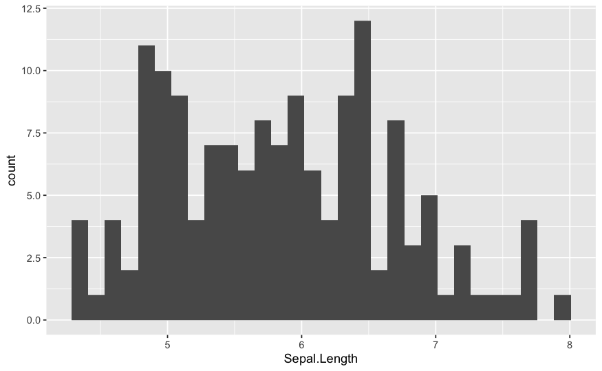

You can use a lot of arguments in the geom_ layer functions. e.g.

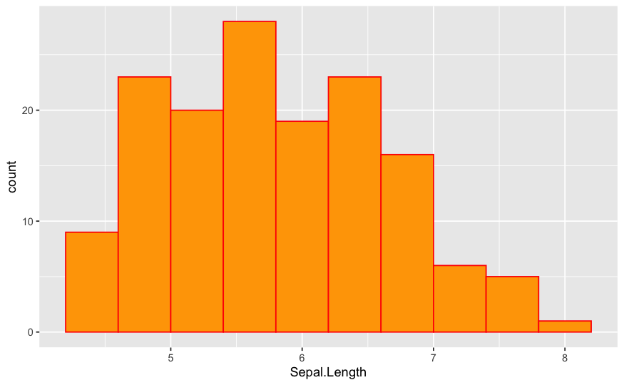

It is easy to change the plot. e.g. below there is a density plot. We only need to change the last line function name

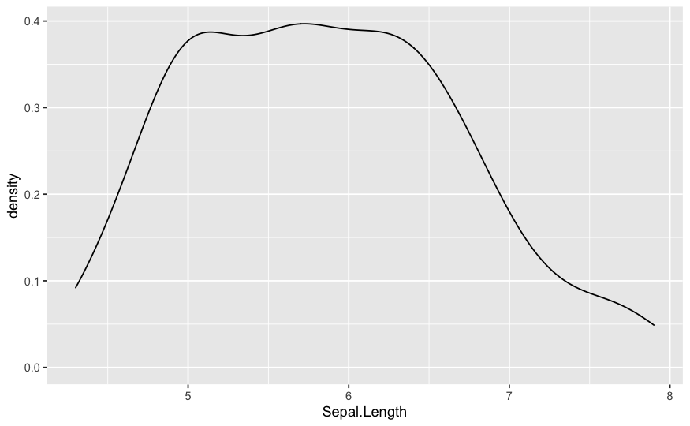

### 2D plots

Create plots with 2 variables in order to show their relationship. We add an additional variable to the aes() function. There are a lot of geom_ functions but the most common are geom_point(), geom_col(), depending on the variables data type.

Below there is a scatter plot

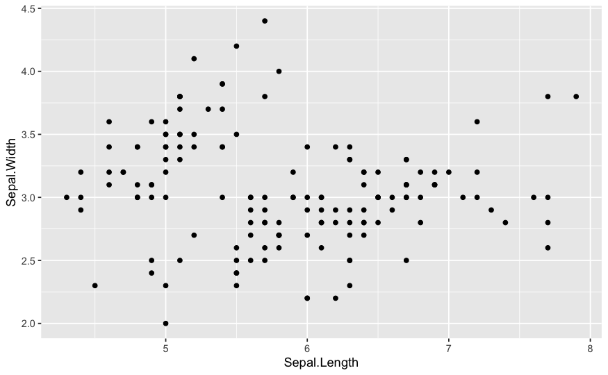

Below there is a bar plot. Here we perform some data transformations prior to the plotting.

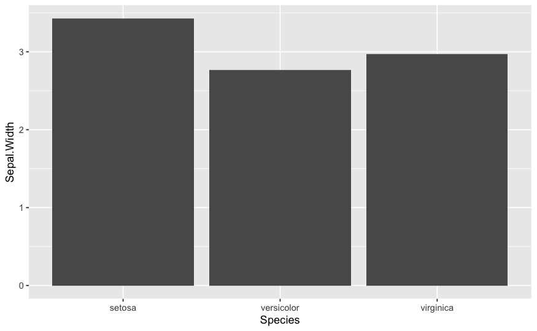

```r
iris %>%
  group_by(Species) %>%
  summarise(Sepal.Width = mean(Sepal.Width)) %>%
  ggplot(aes(Species, Sepal.Width)) +
  geom_col()
```

### Add layers & elements to the plot

Scatter plot with smoothed line (local regression line)

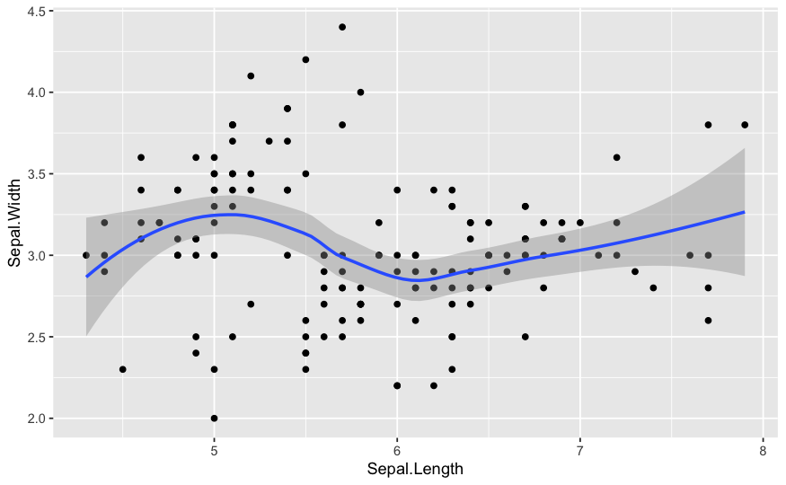

Add a title to the previous plot

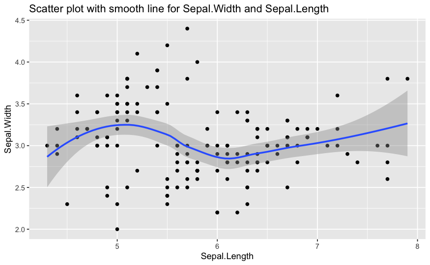

Add a specific theme on the plot

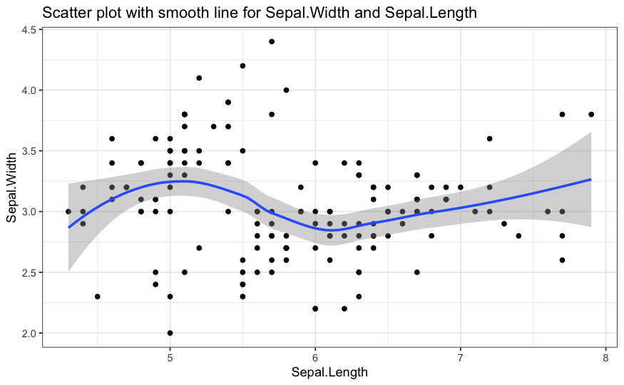

## COMBINE TIDYVERSE PACKAGES

Here we combine tidying, wrangling, grouping, summarizing and plotting data.

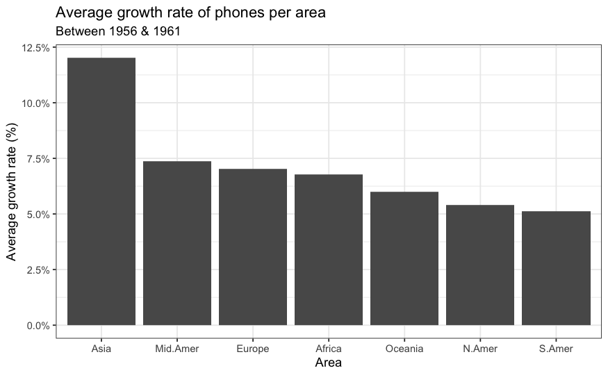

```r
WorldPhones %>%

  # Make a tidy dataset
  as.data.frame() %>%
  rownames_to_column("year") %>%
  gather(key = "Area", value = "Phones", N.Amer:Mid.Amer) %>%
  filter(year > 1951) %>%

  # Create the growth rate variable
  group_by(Area) %>%
  mutate(previous_value = lag(Phones)) %>%
  mutate(growth_rate = (Phones-previous_value)/Phones) %>%

  # Summarise the dataset
  group_by(Area) %>%
  summarise(Avg_growth = mean(growth_rate, na.rm = TRUE)) %>%

  # Create the plot
  ggplot(aes(reorder(Area, -Avg_growth), Avg_growth)) +
  geom_col() +
  labs(
    title = "Average growth rate of phones per area",
    subtitle = "Between 1956 & 1961",
    y = "Average growth rate (%)",
    x = "Area"
  ) +
  scale_y_continuous(labels=scales::percent) +
  theme_bw()
```

## MODELLING

### Linear regression model residuals

Plot the residuals of a linear regression model

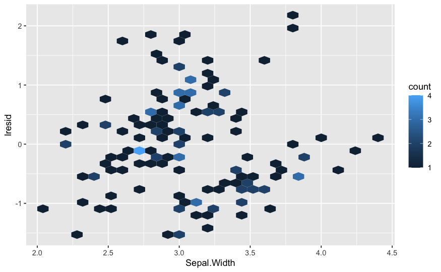

### Multiple models

Fit multiple models in a grouped dataframe. The target here is after developing a linear model between Sepal.Length & Sepal.Width for each Species, report the p value of the Sepal.Width

| Species | term | p.value |
| --- | --- | --- |
| setosa | Sepal.Width | 6.709843e-10 |
| versicolor | Sepal.Width | 8.771860e-05 |
| virginica | Sepal.Width | 8.434625e-04 |